# Analysis of NYC Food inspection

Manroop Singh, Jayesh Borgaonkar

June, 2016

# Introduction

Research has shown that 53% of consumers eat outside the home at least once per week, 17% dine outside the home on average of five or more times per week, and 4% dine outside the home seven or more times in any given week (Jones, Vugia, Selman, Angulo, & EIP FoodNet Working Group, 2002). Given the increasing number of individuals that dine in food service establishments on a daily basis, food safety practices are critical to protecting the health of the public.

Restaurant operations have been reported to be the cause of between 52% and 59% of foodborne illnesses in the United States (Centers for Disease Control and Prevention, 2012b)

Based on all these statistics, we decided to analyse the results of food inspection of various restaurants in New York.

# Problem Description

We obtained a data set of the food inspection results of various restaurant in New York from the New York state website. Based on exploratory and predictory analysis, we wish to make the restaurant inspection process more efficient for the Department of Health and Mental Hygiene. Using the results of our analysis, we wish to determine which restaurants should be inspected first.

# Packages used

To solve this problem, we decided to use the following packages.

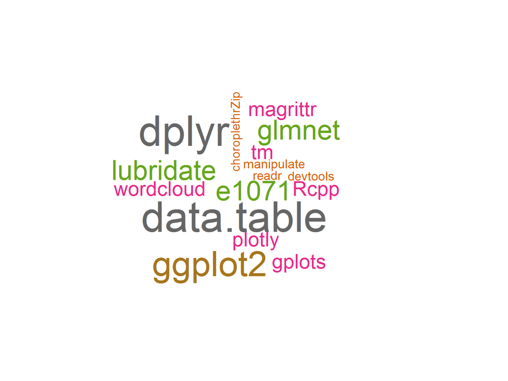

# About the data

Our data set has the following fields

```
- Restaurant Location
- Borough
- Zipcode
- Cuisine
- Score
- Grade
- Inspection type
- Critical Flag
```

The grades are based on scores. The grades are decided based on the following measures

```
Score Range | Grade
------------|---------
 0-13       |  A
 14-27      |  B
 >28        |  C
```

# Cleaning the data

- Eliminated data having:
  - Inspection dates in the year 1900
  - Borough as “Missing”
  - Negative Inspection scores and Empty Inspection scores
- Populated the grades field based on the guidelines of score provided by the Depatment of Health and Mental Hygiene
- Converted the categorical fields of data such as violation code, cuisine, inspection type and critical flag to factors

# Little more about the data

We made an analysis on the number of restaurants by Cuisine and Borough -

- American Cuisine has the maximum number of restaurants and Manhattan has the maximum number of restaurants

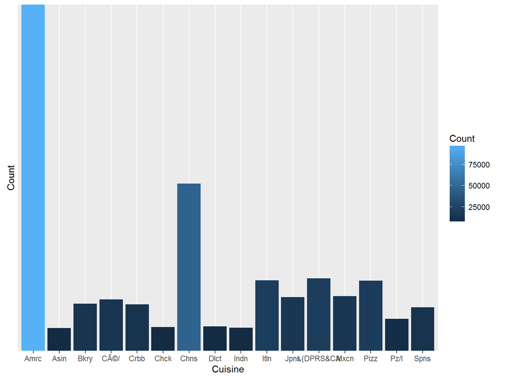

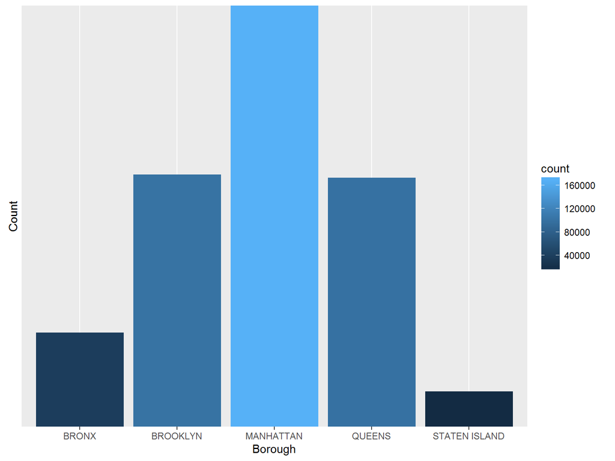

# What are the most common violations in restaurants of New York?

As we can see from the graph plotted below,

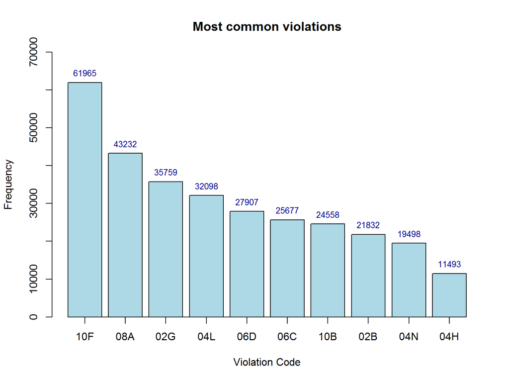

```
## [1] "Facilities-related violations constitute the maximum number of violations, followed closely by Vermin-related violations."
```

# Word cloud of most common violations

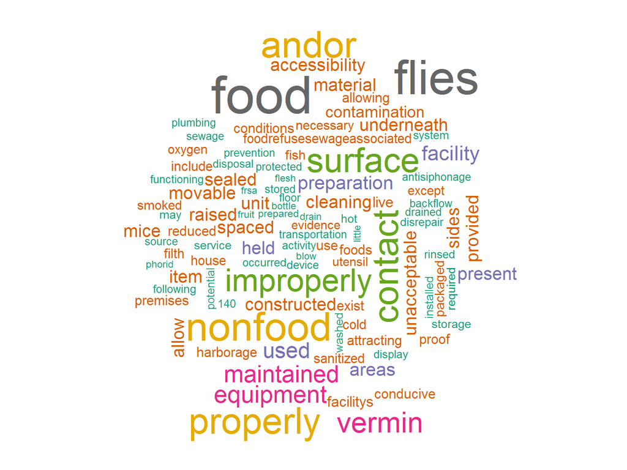

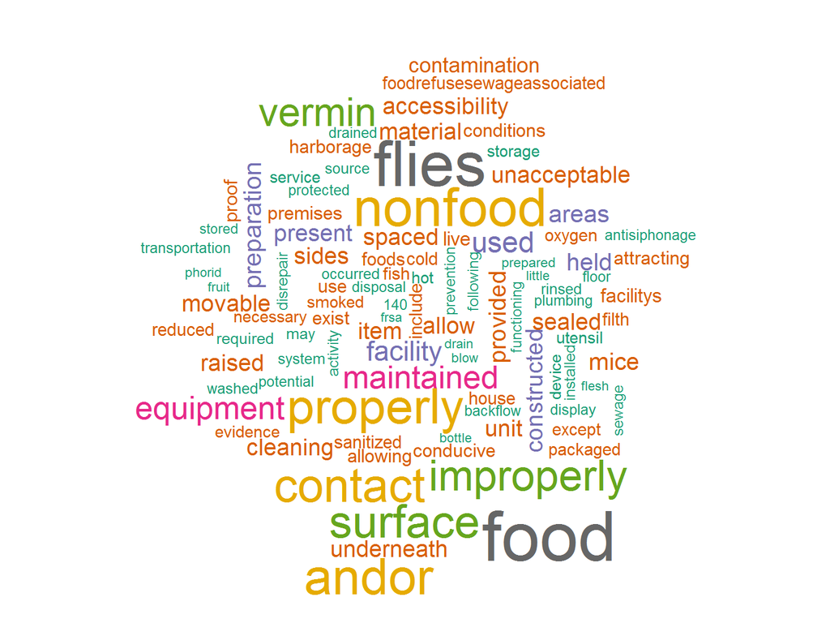

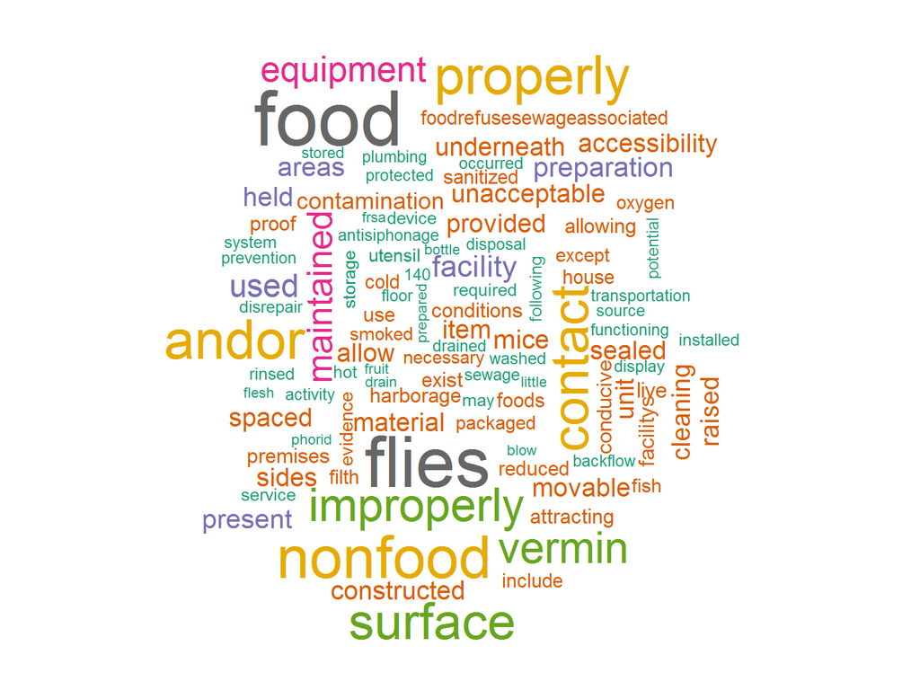

# What are the major categories of food violations?

- We categorized violation codes into the following broad categories:
  - Facilities
  - Vermin
  - Temperature
  - Food
  - Regulatory
  - Contamination
  - Hygiene
  - Smoking

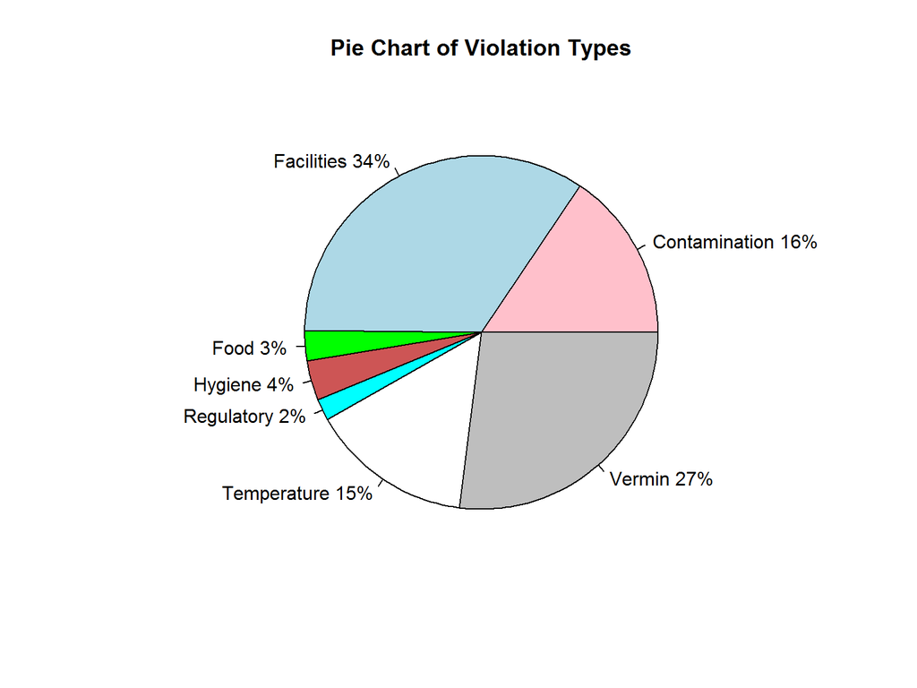

# How is critical flag distributed over violation category?

[interactive chart not shown]

- How are grades distributed over violation category?

[interactive chart not shown]

# Does cuisine have any relationship with critical flag?

[interactive chart not shown]

# How are the restaurants distributed by borough and grade?

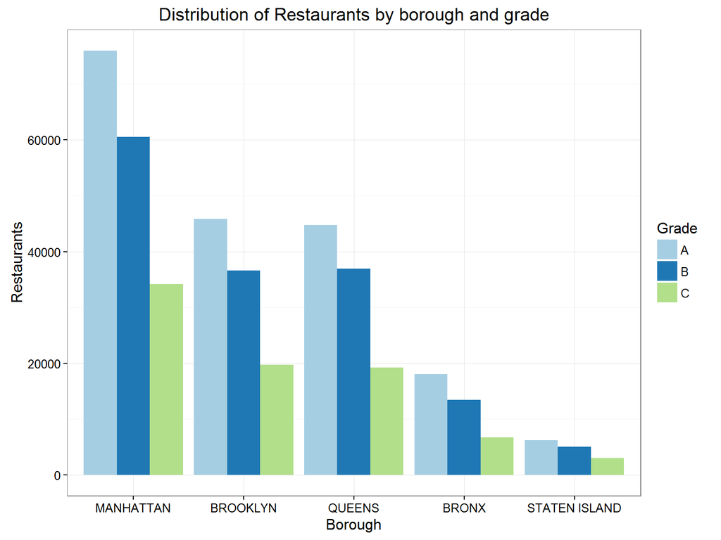